# **33_First_Term**

Suman Paudel

2024-04-10

##### **Question Number 6**

**Solution**

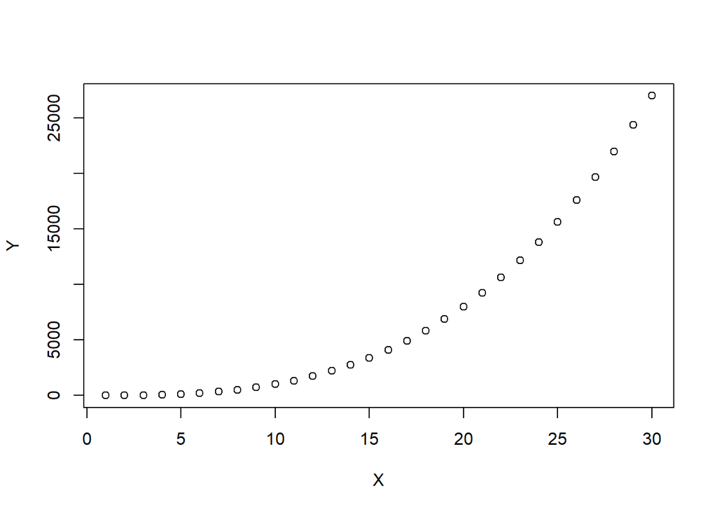

```r
# question number 6
# a
# column vector X from 1 to 30
X <- 1:30


# b
# column vector Y of cubes of vector Y
Y <- X ^ 3

# c
# converted the the X, Y in dataframe
DF <- data.frame(X=X,Y=Y)

# d
# plotted a scatter plot to see relationship between X and Y
plot(X,Y)
```

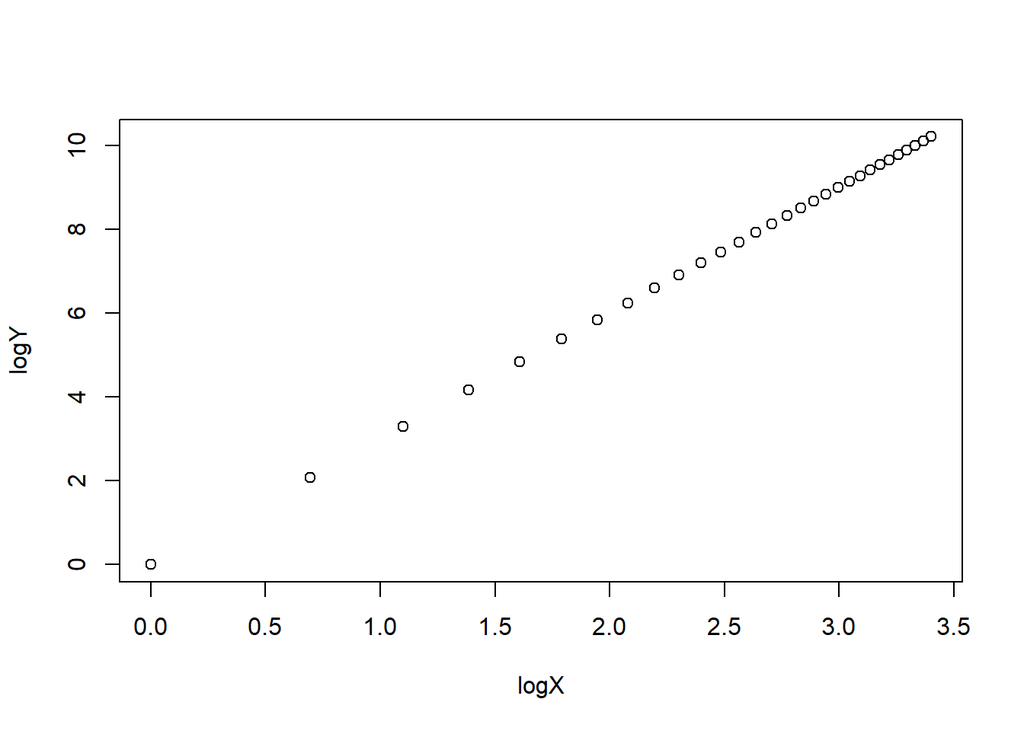

```r
# e
# Since there was no linear relationship we take log of X and Y
logX <- log(X)
logY <- log(Y)

plot(logX, logY)
```

##### **Interpretation**

- 1. Created a vector X with Numbers between 1 and 30
- 2. Created a vector Y with Numbers with cubes of vector 3
- 3. Created a new data.frame called **DF** with vectors X and Y
- 4. Created a scatter plot of X and Y and it is seen that **there no linear relationship between X and Y**.
- 5. Converted the values log to make it linear and then plotted scatter plot again

##### **Question Number 7**

**Solution**

```r
# question number 7
# a
set.seed(33)
roll <- function(die=1:6){
  sample(die, size=2, replace = T)
}

# b
# first roll
roll()
```

```
## [1] 2 6
```

```r
# c
# second roll
roll()
```

```
## [1] 4 1
```

```r
# d
# third roll
roll()
```

```
## [1] 2 4
```

```r
# e
# given a die with sample size two everything we roll we get different rolls in dice
# mimicing the real world dice game
```

##### **Interpretation**

- 1. Created a function **roll()** which has arguments as `die = 1:6`, the die is rolled twice with replacement, to achieve that I have used `sample` function.
- 2. Rolled a die first time and result was 2 and 6
- 3. Rolled a die second time and result was 4 and 1
- 4. Rolled a die first time and result was 2 and 4
- 5. Given a die with sample size two everything we roll we get different rolls in dice mimicking the real world dice game. And every time we roll we will different outcomes and also because replacement is set to true we might get same roll twice occasionally as well.

##### **Question Number 8**

**Solution**

```r
# question number 7

library(tidyverse, warn.conflicts = F)

# a
country_data <- tibble(
  Country = c("USA", "Nepal", "UK", "Germany", "France", "Italy", "Spain", "Japan", "China", "Australia"),
  Year = c(2020, 2021, 2022, 2020, 2021, 2022, 2020, 2021, 2022, 2020),
  Cases = c(10000, 12000, 15000, 8000, 9500, 11000, 7500, 8200, 10500, 6000),
  Population = c(330000000, 37000000, 67000000, 83000000, 67000000, 60000000,
                 47000000, 126000000, 1400000000, 25000000)
)

# b
country_data_long <- country_data %>%
  pivot_longer(cols = c(Year, Population), names_to = "Year", values_to = "Value")

head(country_data_long,n=10)
```

| Country | Cases | Year | Value |
| --- | --- | --- | --- |
| USA | 10000 | Year | 2020 |
| USA | 10000 | Population | 330000000 |
| Nepal | 12000 | Year | 2021 |
| Nepal | 12000 | Population | 37000000 |
| UK | 15000 | Year | 2022 |
| UK | 15000 | Population | 67000000 |
| Germany | 8000 | Year | 2020 |
| Germany | 8000 | Population | 83000000 |
| France | 9500 | Year | 2021 |
| France | 9500 | Population | 67000000 |

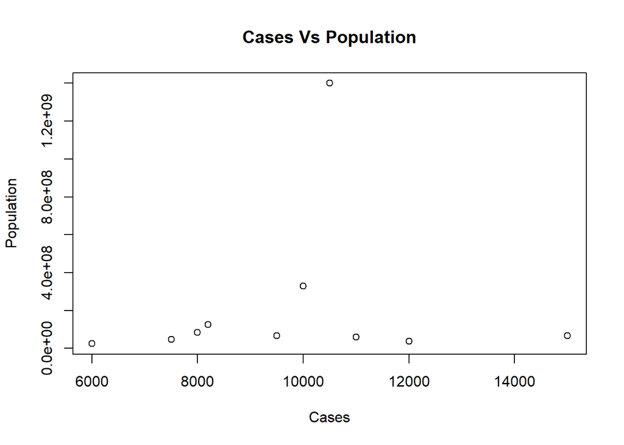

```r
# c
country_data$LnCase <- log(country_data$Cases)
country_data$LnPop <- log(country_data$Population)

# d
plot(country_data$Cases, country_data$Population,main = "Cases Vs Population", xlab='Cases',ylab = 'Population')
```

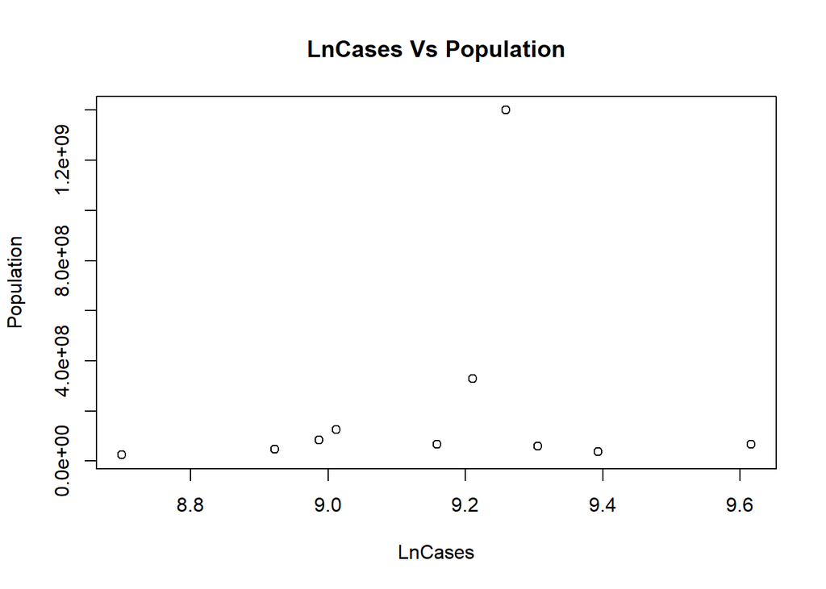

```r
plot(country_data$LnCase, country_data$Population,main = "LnCases Vs Population", xlab='LnCases',ylab = 'Population')
```

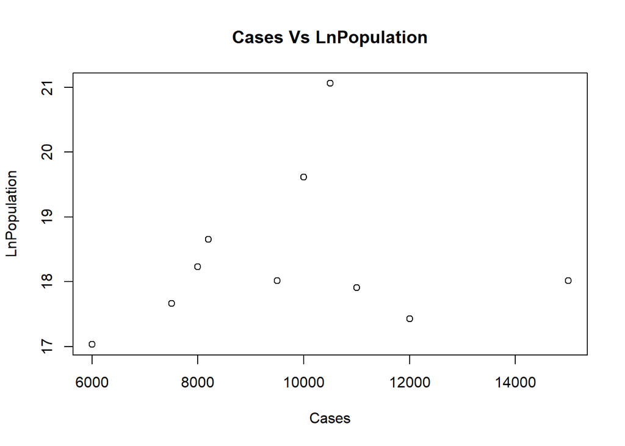

```r
plot(country_data$Cases, country_data$LnPop,main = "Cases Vs LnPopulation",xlab='Cases',ylab = 'LnPopulation')
```

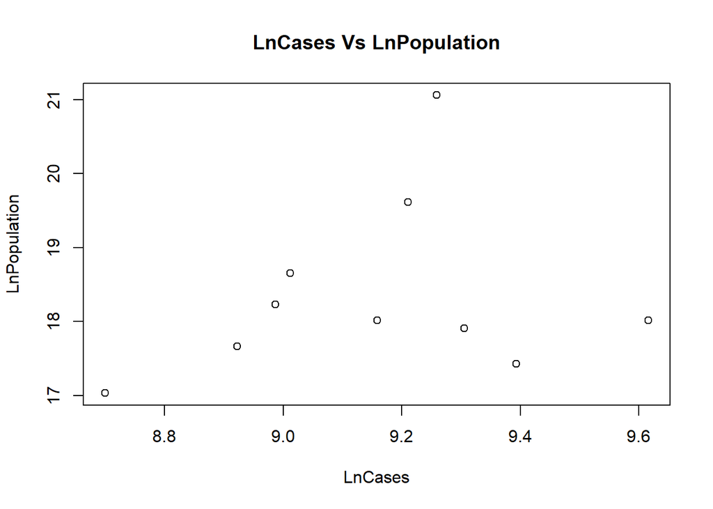

```r
plot(country_data$LnCase, country_data$LnPop,main = "LnCases Vs LnPopulation", xlab='LnCases',ylab = 'LnPopulation')
```

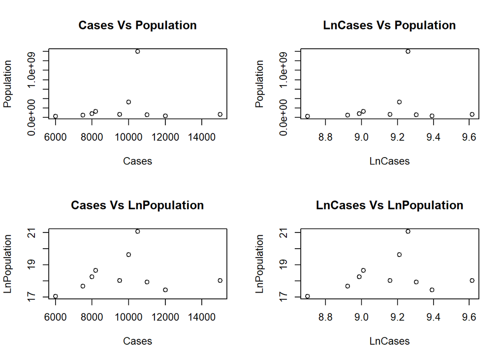

```r
# e
par(mfrow=c(2,2))
plot(country_data$Cases, country_data$Population, main = "Cases Vs Population", xlab='Cases',ylab = 'Population')
plot(country_data$LnCase, country_data$Population,main = "LnCases Vs Population", xlab='LnCases',ylab = 'Population')
plot(country_data$Cases, country_data$LnPop, main = "Cases Vs LnPopulation",xlab='Cases',ylab = 'LnPopulation')
plot(country_data$LnCase, country_data$LnPop,main = "LnCases Vs LnPopulation", xlab='LnCases',ylab = 'LnPopulation')
```

##### **Question Number 9**

**Solution**

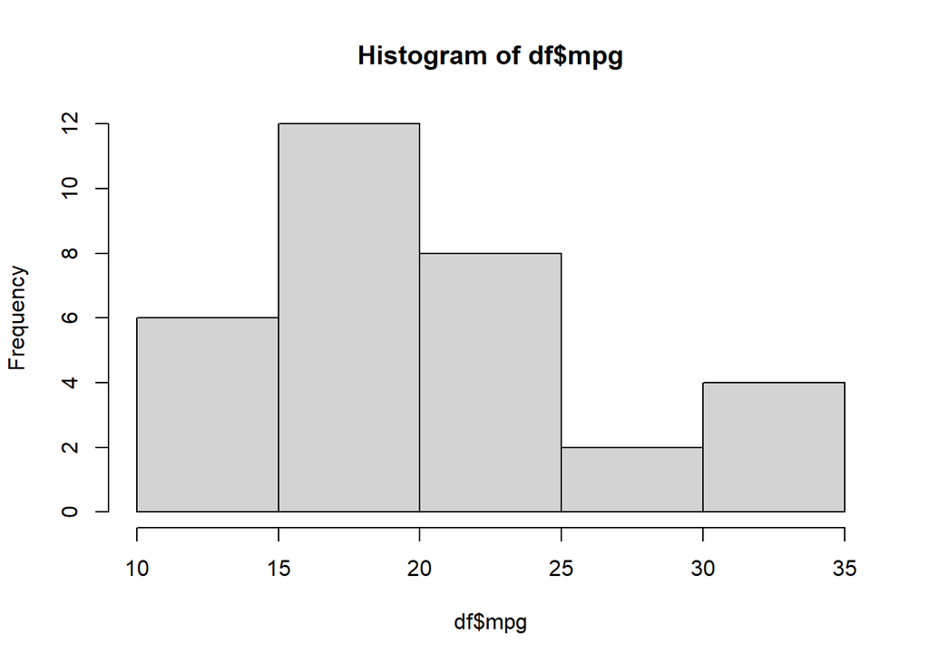

```r
# question number 9
# a
df <- mtcars
hist(df$mpg)
```

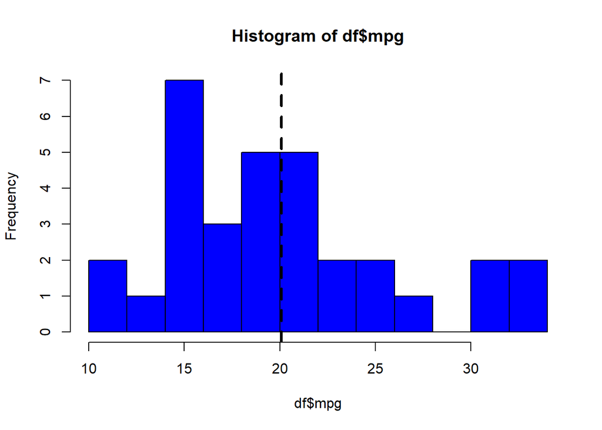

```r
# b
hist(df$mpg,col = 'blue', breaks=10)

# c
abline(v=mean(df$mpg), color='red',lwd=3,lty=2)
```

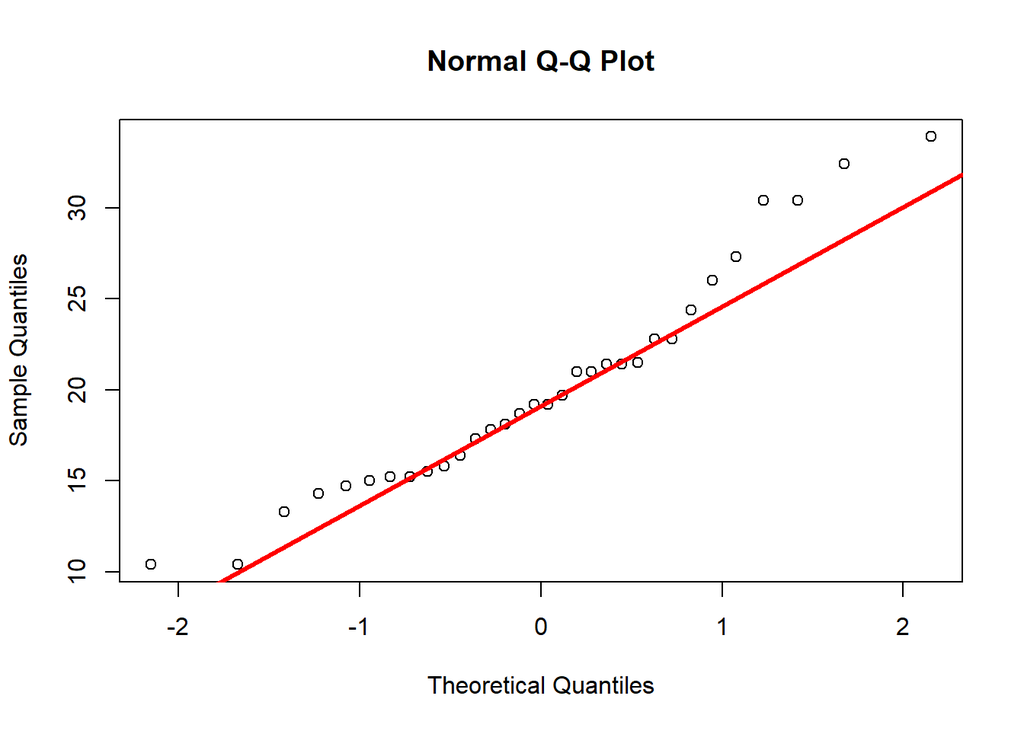

```r
# d
qqnorm(df$mpg)
qqline(df$mpg, col='red', lwd=3)
```

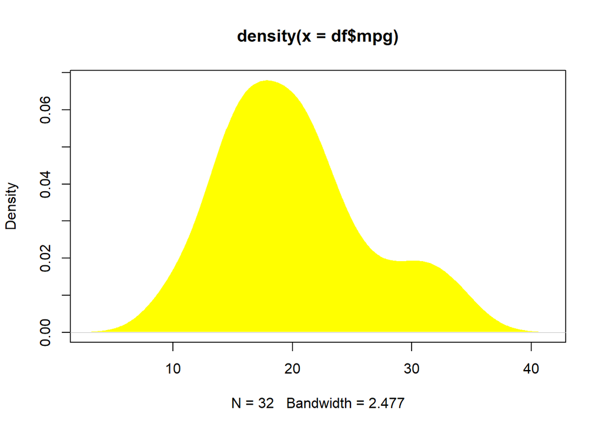

```r
# e
plot(density(df$mpg), type='n')
polygon(density(df$mpg), col='yellow', border = NA)
```

##### **Question Number 10**

**Solution**

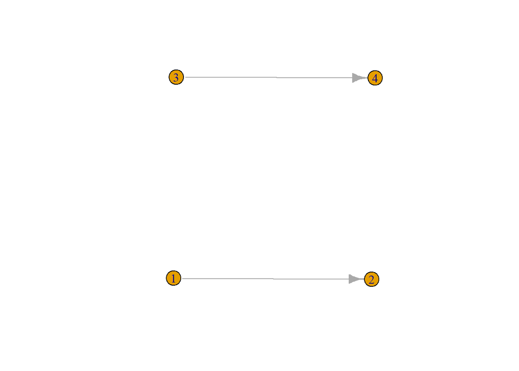

```r
# question number 10

library(igraph, warn.conflicts = F)
library(Rgraphviz, warn.conflicts = F)
# a
g <- graph(c(1,2,3,4))

# b
plot(g)
```

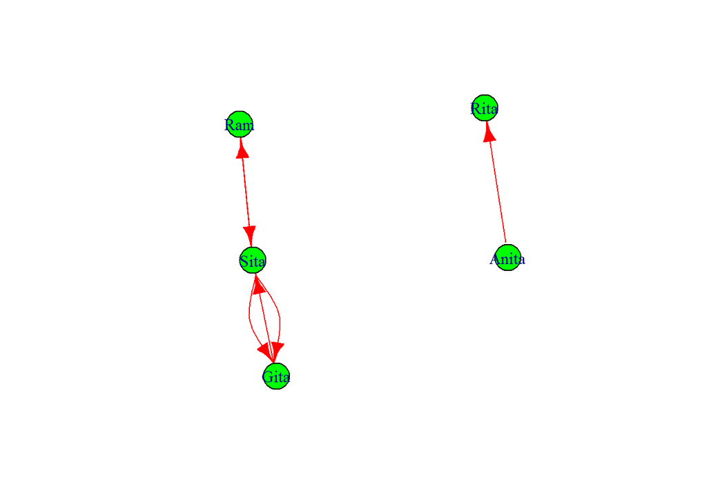

```r
# c
g1 <- graph(c("Sita","Ram","Sita","Gita","Gita","Sita","Sita",
              "Gita","Anita","Rita","Ram","Sita"))
# d
plot(g1, vertex.color='green',vertex.size=20,edge.size=10,edge.color='red')
```

```r
# e
# degree
igraph::degree(g1)
```

```
##  Sita   Ram  Gita Anita  Rita
##     5     2     3     1     1
```

```r
# closeness
closeness(g1,mode = 'in')
```

```
##      Sita       Ram      Gita     Anita      Rita
## 0.5000000 0.3333333 0.3333333       NaN 1.0000000
```

```r
# betweeness
betweenness(g1)
```

```
##  Sita   Ram  Gita Anita  Rita
##     2     0     0     0     0
```

##### **Interpretation**

- 1. define a graph object `g` with (1,2,3,4)
- 2. plotted a graph and we can see that 1 goes to 2 and 3 goes to 4 forming no cycle.
- 3. define a graph object g1 with (“Sita”,“Ram”,“Sita”,“Gita”,“Gita”,“Sita”,“Sita”, “Gita”,“Anita”,“Rita”,“Ram”,“Sita”)) as its elements
- 4. plotted a graph with all of the node color as green and node size as 20, edge color as red and link size as 10, we can see that ram has bi direction cycle between him and Sita, Sita has and Gita both of them has bi drection cycle between them, as Anita has direction going from her to Rita
- - got the degree which show the adjacent edges between nodes,
  - got the closeness which shows how many steps are required to access each vertex from given, here I have taken **‘in’**
  - got the betweenness which shows the numbers paths going thorough one particular vertex